# The Big Three Era

Dominance, Surface, and the Art of Grand Slam Tennis

Haider Saleem — Student ID: 100870637

2026-04-05

# Introduction

Between 2004 and 2023, men’s professional tennis was defined by three players: *Roger Federer*, *Rafael Nadal*, and *Novak Djokovic* collectively known as the “Big Three.” Together, they won 66 Grand Slam titles, rewrote virtually every major record in the sport, and maintained a grip on the ATP rankings almost without interruption for two decades.

This report explores that era using ATP match data from 2004 to 2023. Tennis was chosen because the Big Three era offers a uniquely data-rich case study in sustained athletic dominance across surfaces, tournaments, and time. How dominant were the Big Three compared to their peers? Did surface type shape who won? How did their Grand Slam campaigns unfold round by round, and which tournaments defined each player’s legacy?

The dataset contains over 39,000 ATP match records including tournament metadata, player rankings, ranking points, surfaces, and scores. Data manipulation was performed to filter missing records, engineer year and player category variables, aggregate win counts, and join nationality data for geographic visualisation. The resulting graphics trace the arc of an extraordinary era, one unlikely to be repeated in professional sport.

Federer Wins

Nadal Wins

Djokovic Wins

66

Grand Slams Combined

# Setup & Libraries

```r
library(tidyverse)
library(scales)
library(sf)
library(rnaturalearth)
library(rnaturalearthdata)
library(ggridges)
library(ggtext)
library(glue)
```

# Data Loading & Manipulation

```r
atp_raw <- read_csv("atp_tennis_clean-final.csv")

big3_colours <- c(
  "Federer"  = "#E63946",
  "Nadal"    = "#F4A261",
  "Djokovic" = "#2A9D8F",
  "Other"    = "#636369"
)

# Shared dark theme applied to all ggplots
dark_plot <- theme(
  plot.background   = element_rect(fill = "#232328", colour = NA),
  panel.background  = element_rect(fill = "#232328", colour = NA),
  text              = element_text(colour = "#e8e6e1"),
  axis.text         = element_text(colour = "#b0ada5"),
  axis.title        = element_text(colour = "#ccc9c0"),
  plot.title        = element_text(colour = "#e8e6e1"),
  plot.subtitle     = element_text(colour = "#7a7770"),
  plot.caption      = element_text(colour = "#5a5955"),
  legend.background = element_rect(fill = "transparent", colour = NA),
  legend.key        = element_rect(fill = "transparent", colour = NA),
  legend.text       = element_text(colour = "#b0ada5"),
  legend.title      = element_text(colour = "#ccc9c0")
)

atp <- atp_raw %>%
  mutate(
    Date   = as.Date(Date),
    Year   = as.integer(format(Date, "%Y")),
    P1_won = (Player_1 == Winner),
    Pts_1  = as.numeric(Pts_1),
    Pts_2  = as.numeric(Pts_2),
    Rank_1 = as.numeric(Rank_1),
    Rank_2 = as.numeric(Rank_2)
  ) %>%
  filter(Pts_1 > 0, Pts_2 > 0, Year >= 2004, Year <= 2023) %>%
  mutate(
    Big3 = case_when(
      Winner == "Federer R."  ~ "Federer",
      Winner == "Nadal R."    ~ "Nadal",
      Winner == "Djokovic N." ~ "Djokovic",
      TRUE                    ~ "Other"
    ),
    Surface = factor(Surface, levels = c("Hard", "Clay", "Grass"))
  )

glimpse(atp)
```

```
## Rows: 34,621
## Columns: 17
## $ Tournament <chr> "Rogers Cup", "Rogers Cup", "Rogers Cup", "Rogers Cup", "Ro…
## $ Date       <date> 2005-08-08, 2005-08-08, 2005-08-08, 2005-08-08, 2005-08-08…
## $ Series     <chr> "Masters", "Masters", "Masters", "Masters", "Masters", "Mas…
## $ Surface    <fct> Hard, Hard, Hard, Hard, Hard, Hard, Hard, Hard, Hard, Hard,…
## $ Round      <chr> "1st Round", "1st Round", "1st Round", "1st Round", "1st Ro…
## $ `Best of`  <dbl> 3, 3, 3, 3, 3, 3, 3, 3, 3, 3, 3, 3, 3, 3, 3, 3, 3, 3, 3, 3,…
## $ Player_1   <chr> "Bester P.", "Pavel A.", "Saulnier C.", "Gasquet R.", "Kim …
## $ Player_2   <chr> "Mello R.", "Rochus C.", "Ancic M.", "Youzhny M.", "Robredo…
## $ Winner     <chr> "Mello R.", "Pavel A.", "Ancic M.", "Gasquet R.", "Robredo …
## $ Rank_1     <dbl> 978, 38, 68, 18, 77, 35, 13, 44, 42, 30, 52, 8, 55, 7, 62, …
## $ Rank_2     <dbl> 56, 48, 29, 25, 22, 172, 26, 164, 129, 19, 12, 54, 40, 61, …
## $ Pts_1      <dbl> 7, 855, 555, 1425, 511, 983, 1510, 812, 835, 1105, 675, 187…
## $ Pts_2      <dbl> 648, 739, 1115, 1245, 1290, 240, 1241, 255, 348, 1385, 1650…
## $ Score      <chr> "4-6 2-6", "6-1 7-5", "3-6 6-7", "6-3 7-6", "5-7 6-3 1-6", …
## $ Year       <int> 2005, 2005, 2005, 2005, 2005, 2005, 2005, 2005, 2005, 2005,…
## $ P1_won     <lgl> FALSE, TRUE, FALSE, TRUE, FALSE, TRUE, FALSE, TRUE, FALSE, …
## $ Big3       <chr> "Other", "Other", "Other", "Other", "Other", "Other", "Othe…
```

```r
wins_by_player_year <- atp %>%
  group_by(Year, Big3) %>%
  summarise(Wins = n(), .groups = "drop")

top_players <- atp %>%
  group_by(Winner) %>%
  summarise(Wins = n(), .groups = "drop") %>%
  arrange(desc(Wins)) %>%
  slice_head(n = 20) %>%
  mutate(
    Category = case_when(
      Winner == "Federer R."  ~ "Federer",
      Winner == "Nadal R."    ~ "Nadal",
      Winner == "Djokovic N." ~ "Djokovic",
      TRUE                    ~ "Other"
    )
  )

big3_surface <- atp %>%
  filter(Big3 != "Other") %>%
  group_by(Big3, Surface) %>%
  summarise(Wins = n(), .groups = "drop") %>%
  group_by(Big3) %>%
  mutate(WinPct = Wins / sum(Wins))

country_wins <- atp %>%
  mutate(
    Country = case_when(
      str_detect(Winner, "Federer")    ~ "CHE",
      str_detect(Winner, "Nadal")      ~ "ESP",
      str_detect(Winner, "Djokovic")   ~ "SRB",
      str_detect(Winner, "Murray")     ~ "GBR",
      str_detect(Winner, "Ferrer")     ~ "ESP",
      str_detect(Winner, "Roddick")    ~ "USA",
      str_detect(Winner, "Hewitt")     ~ "AUS",
      str_detect(Winner, "Berdych")    ~ "CZE",
      str_detect(Winner, "Wawrinka")   ~ "CHE",
      str_detect(Winner, "Zverev")     ~ "DEU",
      str_detect(Winner, "Gasquet")    ~ "FRA",
      str_detect(Winner, "Monfils")    ~ "FRA",
      str_detect(Winner, "Tsitsipas")  ~ "GRC",
      str_detect(Winner, "Medvedev")   ~ "RUS",
      str_detect(Winner, "Alcaraz")    ~ "ESP",
      str_detect(Winner, "Cilic")      ~ "HRV",
      str_detect(Winner, "Verdasco")   ~ "ESP",
      str_detect(Winner, "Robredo")    ~ "ESP",
      str_detect(Winner, "Davydenko")  ~ "RUS",
      str_detect(Winner, "Lopez")      ~ "ESP",
      str_detect(Winner, "Isner")      ~ "USA",
      str_detect(Winner, "Simon")      ~ "FRA",
      str_detect(Winner, "Youzhny")    ~ "RUS",
      str_detect(Winner, "Nalbandian") ~ "ARG",
      str_detect(Winner, "Coria")      ~ "ARG",
      str_detect(Winner, "Safin")      ~ "RUS",
      str_detect(Winner, "Haas")       ~ "DEU",
      str_detect(Winner, "Stepanek")   ~ "CZE",
      str_detect(Winner, "Thiem")      ~ "AUT",
      str_detect(Winner, "Berrettini") ~ "ITA",
      str_detect(Winner, "Sinner")     ~ "ITA",
      TRUE ~ NA_character_
    )
  ) %>%
  filter(!is.na(Country)) %>%
  group_by(Country) %>%
  summarise(Wins = n(), .groups = "drop")
```

# Figures

## Figure 1 — Choropleth Map: ATP Wins by Player Nationality

Which countries produced the most ATP match winners across the Big Three era?

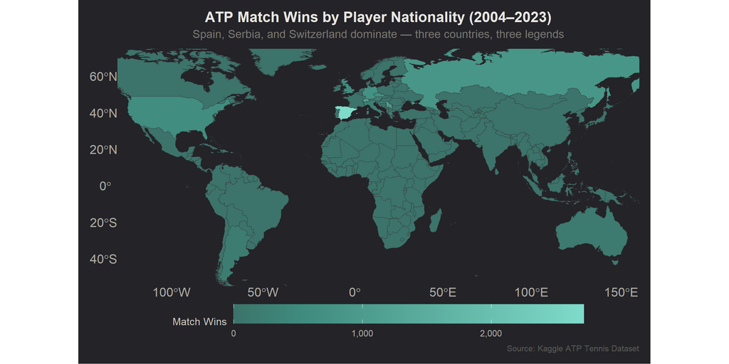

```r
world <- ne_countries(scale = "medium", returnclass = "sf")

world_wins <- world %>%
  left_join(country_wins, by = c("iso_a3" = "Country")) %>%
  mutate(Wins = replace_na(Wins, 0))

ggplot(world_wins) +
  geom_sf(aes(fill = Wins), colour = "#333338", linewidth = 0.15) +
  scale_fill_gradient2(
    low = "#2a2a30", mid = "#3e8a7c", high = "#7FDBCA",
    midpoint = 500, na.value = "#28282e",
    name = "Match Wins", labels = label_comma()
  ) +
  coord_sf(xlim = c(-130, 160), ylim = c(-55, 75), expand = FALSE) +
  labs(
    title    = "ATP Match Wins by Player Nationality (2004–2023)",
    subtitle = "Spain, Serbia, and Switzerland dominate — three countries, three legends",
    caption  = "Source: Kaggle ATP Tennis Dataset"
  ) +
  theme_void() +
  theme(
    plot.title       = element_text(size = 13, face = "bold", hjust = 0.5, margin = margin(b = 4), colour = "#e8e6e1"),
    plot.subtitle    = element_text(size = 10, hjust = 0.5, colour = "#7a7770", margin = margin(b = 8)),
    legend.position  = "bottom",
    legend.key.width = unit(2.2, "cm"),
    legend.title     = element_text(size = 9, colour = "#b0ada5"),
    legend.text      = element_text(size = 8, colour = "#b0ada5"),
    plot.caption     = element_text(size = 7.5, colour = "#5a5955", margin = margin(t = 6)),
    plot.background  = element_rect(fill = "#232328", colour = NA),
    plot.margin      = margin(10, 10, 10, 10)
  ) + dark_plot
```

**Key insight:** Spain leads decisively, driven not only by Nadal but a deep bench of top-100 players including Ferrer, Verdasco, and Robredo. Switzerland punches far above its weight thanks to Federer and Wawrinka, while Serbia’s win count is almost entirely attributable to Djokovic alone.

## Figure 2 — Lollipop Chart: Top 20 Players by Total Wins

Just how far ahead of the field were Federer, Nadal, and Djokovic?

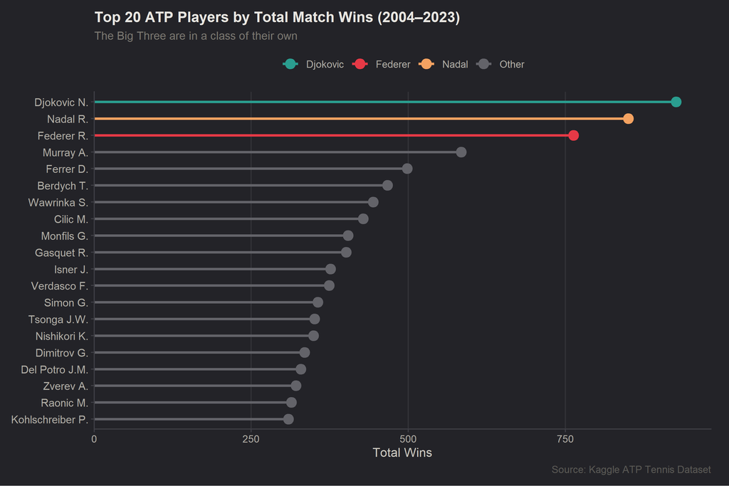

```r
top_players %>%
  mutate(Winner = fct_reorder(Winner, Wins)) %>%
  ggplot(aes(x = Winner, y = Wins, colour = Category)) +
  geom_segment(aes(xend = Winner, y = 0, yend = Wins), linewidth = 1.1) +
  geom_point(size = 4) +
  scale_colour_manual(values = big3_colours, name = NULL) +
  scale_y_continuous(labels = label_comma(), expand = expansion(mult = c(0, 0.06))) +
  coord_flip() +
  labs(
    title    = "Top 20 ATP Players by Total Match Wins (2004–2023)",
    subtitle = "The Big Three are in a class of their own",
    x = NULL, y = "Total Wins", caption = "Source: Kaggle ATP Tennis Dataset"
  ) +
  theme_classic() +
  theme(
    plot.title         = element_text(size = 13, face = "bold"),
    plot.subtitle      = element_text(size = 10),
    legend.position    = "top",
    axis.text.y        = element_text(size = 9.5),
    axis.text.x        = element_text(size = 9),
    panel.grid.major.x = element_line(colour = "#333338", linewidth = 0.5),
    axis.line          = element_line(colour = "#3e3e45"),
    axis.ticks         = element_line(colour = "#3e3e45"),
    plot.margin        = margin(10, 16, 10, 10)
  ) +
  dark_plot
```

## Figure 3 — Line Chart: Season Win Totals Over Time

How did each player’s annual win count rise and fall across two decades?

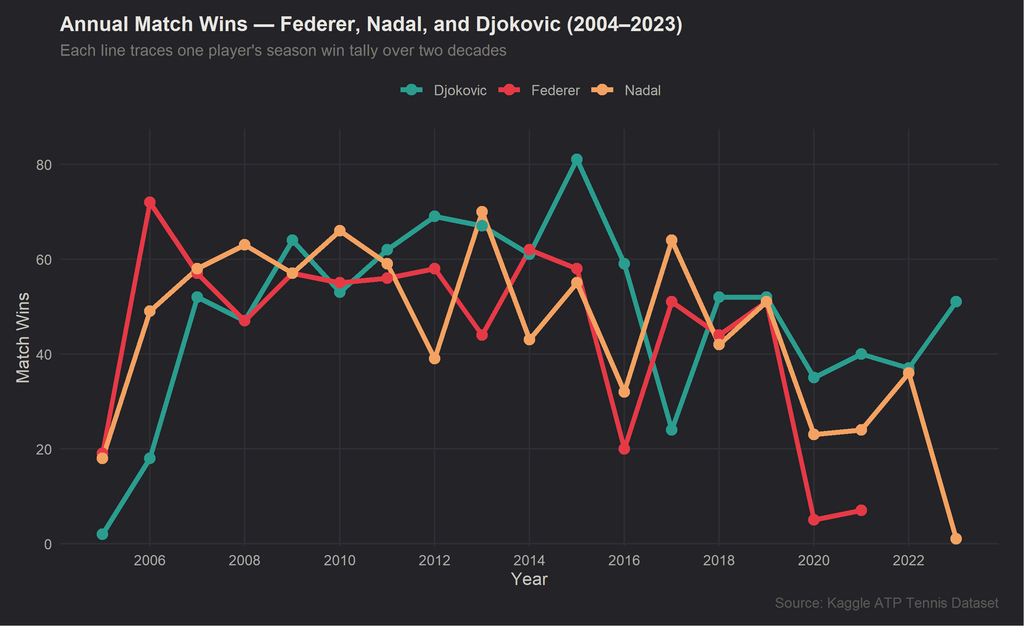

```r
wins_by_player_year %>%
  filter(Big3 != "Other") %>%
  ggplot(aes(x = Year, y = Wins, colour = Big3, group = Big3)) +
  geom_line(linewidth = 1.5) +
  geom_point(size = 3) +
  scale_colour_manual(values = big3_colours, name = NULL) +
  scale_x_continuous(breaks = seq(2004, 2023, by = 2)) +
  scale_y_continuous(labels = label_comma(), expand = expansion(mult = c(0.02, 0.08))) +
  labs(
    title    = "Annual Match Wins — Federer, Nadal, and Djokovic (2004–2023)",
    subtitle = "Each line traces one player's season win tally over two decades",
    x = "Year", y = "Match Wins", caption = "Source: Kaggle ATP Tennis Dataset"
  ) +
  theme_minimal() +
  theme(
    plot.title       = element_text(size = 13, face = "bold"),
    plot.subtitle    = element_text(size = 10),
    legend.position  = "top",
    panel.grid.minor = element_blank(),
    panel.grid.major = element_line(colour = "#2e2e34"),
    plot.margin      = margin(10, 16, 10, 10)
  ) +
  dark_plot
```

## Figure 4 — Heatmap: Win Share by Surface

Each player is famously associated with a surface — does the data confirm it?

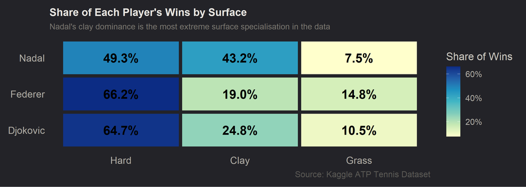

```r
big3_surface %>%
  ggplot(aes(x = Surface, y = Big3, fill = WinPct)) +
  geom_tile(colour = "#232328", linewidth = 2) +
  geom_text(aes(label = percent(WinPct, accuracy = 0.1)),
            size = 5.5, fontface = "bold", colour = "black") +
  scale_fill_distiller(palette = "YlGnBu", direction = 1,
                       name = "Share of Wins", labels = label_percent()) +
  labs(
    title    = "Share of Each Player's Wins by Surface",
    subtitle = "Nadal's clay dominance is the most extreme surface specialisation in the data",
    x = NULL, y = NULL, caption = "Source: Kaggle ATP Tennis Dataset"
  ) +
  theme_minimal(base_size = 13) +
  theme(
    plot.title      = element_text(size = 13, face = "bold"),
    plot.subtitle   = element_text(size = 10),
    axis.text       = element_text(size = 12),
    legend.position = "right",
    panel.grid      = element_blank(),
    plot.margin     = margin(10, 10, 10, 10)
  ) +
  dark_plot
```

## Figure 5 — Scatter Plot: Season Wins vs. Average Opponent Ranking

Did the Big Three win more when facing weaker draws, or did they dominate regardless?

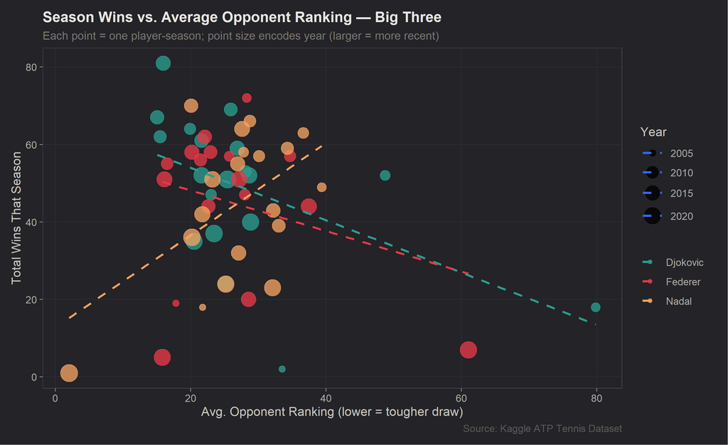

```r
scatter_data <- atp %>%
  filter(Big3 != "Other") %>%
  group_by(Big3, Year) %>%
  summarise(Wins = n(), AvgOppRank = mean(Rank_2, na.rm = TRUE), .groups = "drop")

ggplot(scatter_data, aes(x = AvgOppRank, y = Wins, colour = Big3, size = Year)) +
  geom_point(alpha = 0.78) +
  geom_smooth(aes(group = Big3), method = "lm", se = FALSE,
              linewidth = 0.9, linetype = "dashed") +
  scale_colour_manual(values = big3_colours, name = NULL) +
  scale_size_continuous(range = c(2.5, 7), name = "Year") +
  scale_x_continuous(labels = label_comma()) +
  scale_y_continuous(labels = label_comma()) +
  labs(
    title    = "Season Wins vs. Average Opponent Ranking — Big Three",
    subtitle = "Each point = one player-season; point size encodes year (larger = more recent)",
    x = "Avg. Opponent Ranking (lower = tougher draw)", y = "Total Wins That Season",
    caption  = "Source: Kaggle ATP Tennis Dataset"
  ) +
  theme_light() +
  theme(
    plot.title       = element_text(size = 13, face = "bold"),
    plot.subtitle    = element_text(size = 10),
    legend.position  = "right",
    panel.grid.minor = element_blank(),
    panel.grid.major = element_line(colour = "#2e2e34"),
    panel.border     = element_rect(colour = "#3e3e45"),
    plot.margin      = margin(10, 16, 10, 10)
  ) +
  dark_plot
```

## Figure 6 — Ridgeline Plot: Distribution of Wins Across Years

When did each player’s peak years cluster? *(Novel — ggridges)*

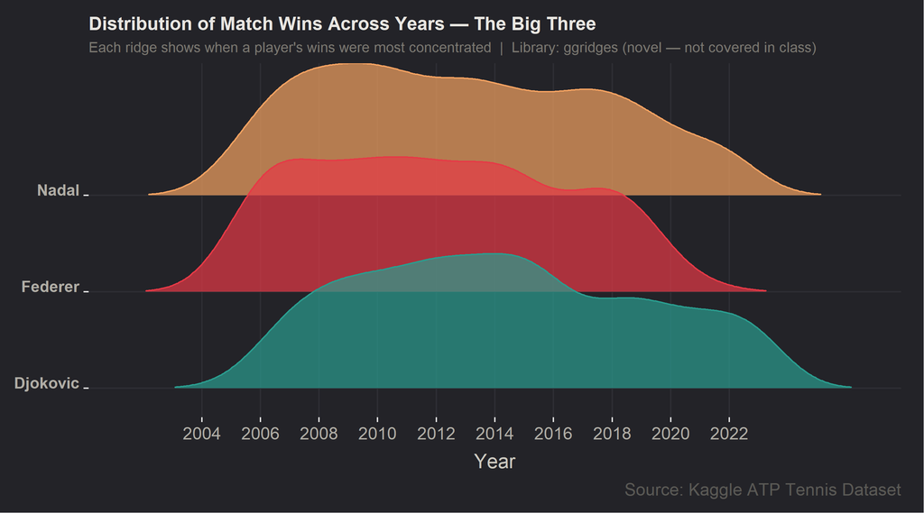

```r
ridge_data <- atp %>%
  filter(Big3 != "Other") %>%
  group_by(Big3, Year) %>%
  summarise(Wins = n(), .groups = "drop") %>%
  ungroup() %>%
  tidyr::uncount(Wins)

ggplot(ridge_data, aes(x = Year, y = Big3, fill = Big3, colour = Big3)) +
  ggridges::geom_density_ridges(
    alpha = 0.7, scale = 1.4, rel_min_height = 0.008,
    bandwidth = 1.2
  ) +
  scale_fill_manual(values = big3_colours, guide = "none") +
  scale_colour_manual(values = big3_colours, guide = "none") +
  scale_x_continuous(breaks = seq(2004, 2023, by = 2)) +
  scale_y_discrete(expand = expansion(add = c(0.3, 1.2))) +
  labs(
    title    = "Distribution of Match Wins Across Years — The Big Three",
    subtitle = "Each ridge shows when a player's wins were most concentrated  |  Library: ggridges (novel — not covered in class)",
    x = "Year", y = NULL, caption = "Source: Kaggle ATP Tennis Dataset"
  ) +
  theme_ridges(grid = TRUE, center_axis_labels = TRUE) +
  theme(
    plot.title       = element_text(size = 13, face = "bold"),
    plot.subtitle    = element_text(size = 10),
    axis.text.y      = element_text(size = 11, face = "bold"),
    panel.grid.major = element_line(colour = "#2e2e34"),
    plot.margin      = margin(10, 16, 10, 10)
  ) +
  dark_plot
```

## Figure 7 — Faceted Bar Chart: Grand Slam Wins by Round

How did each player’s win volume distribute across Grand Slam rounds?

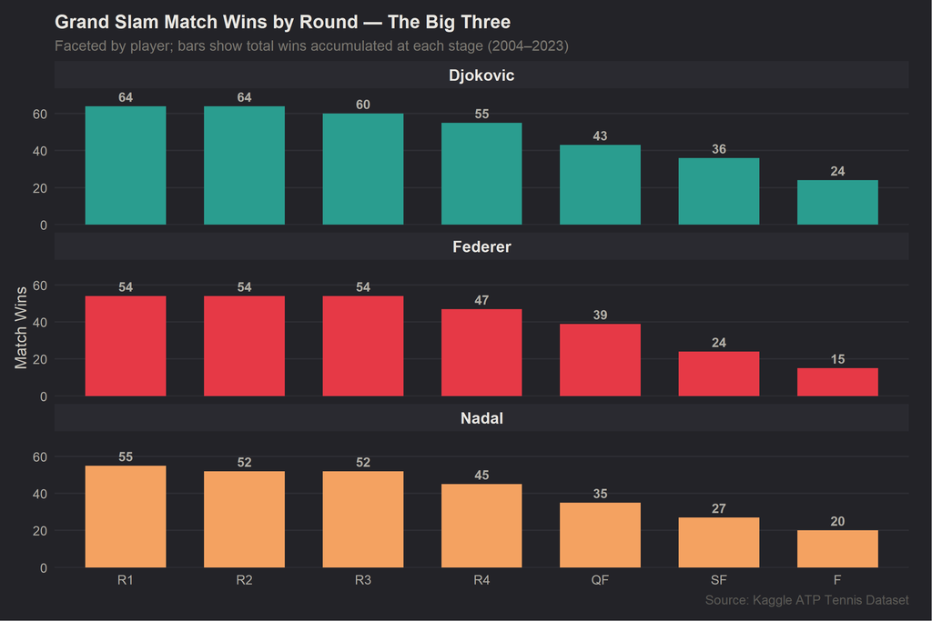

```r
gs_bar_data <- atp %>%
  filter(Series == "Grand Slam", Big3 != "Other") %>%
  mutate(Round = factor(Round,
    levels = c("1st Round","2nd Round","3rd Round","4th Round",
               "Quarterfinals","Semifinals","The Final"))) %>%
  count(Big3, Round) %>%
  filter(!is.na(Round))

ggplot(gs_bar_data, aes(x = Round, y = n, fill = Big3)) +
  geom_col(width = 0.68) +
  geom_text(aes(label = n), vjust = -0.5, size = 3.2, fontface = "bold", colour = "#b0ada5") +
  facet_wrap(~ Big3, ncol = 1) +
  scale_fill_manual(values = big3_colours, guide = "none") +
  scale_y_continuous(expand = expansion(mult = c(0, 0.15))) +
  scale_x_discrete(labels = c(
    "1st Round" = "R1", "2nd Round" = "R2", "3rd Round" = "R3",
    "4th Round" = "R4", "Quarterfinals" = "QF", "Semifinals" = "SF", "The Final" = "F"
  )) +
  labs(
    title    = "Grand Slam Match Wins by Round — The Big Three",
    subtitle = "Faceted by player; bars show total wins accumulated at each stage (2004–2023)",
    x = NULL, y = "Match Wins", caption = "Source: Kaggle ATP Tennis Dataset"
  ) +
  theme_minimal() +
  theme(
    plot.title         = element_text(size = 13, face = "bold"),
    plot.subtitle      = element_text(size = 10),
    strip.text         = element_text(face = "bold", size = 11, colour = "#e8e6e1"),
    strip.background   = element_rect(fill = "#2a2a30", colour = NA),
    panel.grid.major.x = element_blank(),
    panel.grid.minor   = element_blank(),
    panel.grid.major.y = element_line(colour = "#2e2e34"),
    plot.margin        = margin(10, 16, 10, 10)
  ) +
  dark_plot
```

# References

- ATP Tennis Dataset (2000–2026): https://www.kaggle.com/datasets/dissfya/atp-tennis-2000-2023daily-pull/data

- rnaturalearth package: https://cran.r-project.org/web/packages/rnaturalearth/readme/README.html

- ggridges package: https://cran.r-project.org/web/packages/ggridges/vignettes/introduction.html

- scales package: https://scales.r-lib.org/

# AI Prompts

The following prompts were used with AI tools for code optimisation only:

- *“How do I use left_join to merge an sf world object with a data frame by ISO country code?”*
- *“How do I use ggridges geom_density_ridges with uncounted win data to show temporal distribution?”*
- *“What does scale_fill_distiller do differently from scale_fill_gradient2?”*
- *“How do I add geom_text labels above geom_col bars in a faceted ggplot?”*
- *“How do I prevent horizontal overflow in an R Notebook HTML output?”*